# Exploratory Data Analysis on HIV Trends, Neonatal & Under-five Mortality Rates

Kelvin Ziro

2025-04-27

## Data Acquisition & Report Setup

### Dependencies

```r
# Run these in the console
install.packages("reticulate")
py_install(c("numpy", "pandas", "geopandas", "matplotlib", "seaborn", "re"))
```

```python
# Import libraries & data
import numpy as np
import pandas as pd
import geopandas as gpd
import matplotlib.pyplot as plt
import seaborn as sns
import re

# Data importation
hiv_df = pd.read_csv("data/datasets/hiv_data_2000_2023.csv")
under_five_df = pd.read_csv("data/datasets/under_five_mortality_rate.csv")
noenatal_df = pd.read_csv("data/datasets/neonatal_mortality_rate.csv")
multidimensional_df = pd.read_excel("data/datasets/multidimensional_poverty.xlsx")
child_mort_df = pd.read_csv("data/datasets/dataset_datascience.csv")
```

## Project Source

[CEMA-training, Data Science Internship Track](https://github.com/CEMA-training/internship_task_dscience?tab=readme-ov-file)

## Data Cleaning & Initial EDA

```python
hiv_df.info()
```

```
## <class 'pandas.core.frame.DataFrame'>
## RangeIndex: 1552 entries, 0 to 1551
## Data columns (total 11 columns):
##  #   Column               Non-Null Count  Dtype
## ---  ------               --------------  -----
##  0   IndicatorCode        1552 non-null   object
##  1   Indicator            1552 non-null   object
##  2   ValueType            1552 non-null   object
##  3   ParentLocationCode   1552 non-null   object
##  4   ParentLocation       1552 non-null   object
##  5   Location type        1552 non-null   object
##  6   SpatialDimValueCode  1552 non-null   object
##  7   Location             1552 non-null   object
##  8   Period type          1552 non-null   object
##  9   Period               1552 non-null   int64
##  10  Value                1552 non-null   object
## dtypes: int64(1), object(10)
## memory usage: 133.5+ KB
```

```python
hiv_df.head()
```

```
##     IndicatorCode  ...                        Value
## 0  HIV_0000000001  ...  320 000 [280 000 - 380 000]
## 1  HIV_0000000001  ...  320 000 [280 000 - 380 000]
## 2  HIV_0000000001  ...  320 000 [280 000 - 380 000]
## 3  HIV_0000000001  ...  320 000 [280 000 - 370 000]
## 4  HIV_0000000001  ...  300 000 [260 000 - 350 000]
##
## [5 rows x 11 columns]
```

```python
hiv_df.tail()
```

```
##        IndicatorCode  ...    Value
## 1547  HIV_0000000001  ...  No data
## 1548  HIV_0000000001  ...  No data
## 1549  HIV_0000000001  ...  No data
## 1550  HIV_0000000001  ...  No data
## 1551  HIV_0000000001  ...  No data
##
## [5 rows x 11 columns]
```

**Dimensions**:

- Observations: *1552*
- Variables: *11 (1 of int64 type, the rest are of object type)*

**Variables of interest**:

- ParentLocationCode
- ParentLocation
- Location
- Period
- Value

### ParentLocationCode & ParentLocation

```python
print(hiv_df["ParentLocationCode"].unique())
```

```
## ['AFR' 'AMR' 'EMR' 'EUR' 'SEAR' 'WPR']
```

```python
print(hiv_df["ParentLocation"].unique())
```

```
## ['Africa' 'Americas' 'Eastern Mediterranean' 'Europe' 'South-East Asia'
##  'Western Pacific']
```

We have a total of `6` regions recorded in the dataset as `ParentLocation`s along with their codes.

### Location

```python
unique_locations = hiv_df["Location"].unique()
len(unique_locations)
```

```
## 194
```

`194` Unique locations are recorded in the dataset

### Period

```python
years_recorded = hiv_df["Period"].unique()
years_recorded
```

```
## array([2023, 2022, 2021, 2020, 2015, 2010, 2005, 2000])
```

`8` different years are recorded in the dataset.

### Value

```python
# Inspect the Value column
hiv_df["Value"].value_counts()
```

```
## Value
## No data                        394
## <500 [<500 - <500]              26
## <200 [<100 - <200]               9
## <100 [<100 - <100]               8
## 140 000 [120 000 - 160 000]      8
##                               ...
## 51 000 [44 000 - 58 000]         1
## 49 000 [43 000 - 56 000]         1
## 48 000 [42 000 - 54 000]         1
## 46 000 [41 000 - 52 000]         1
## 180 000 [150 000 - 200 000]      1
## Name: count, Length: 895, dtype: int64
```

Assuming that the value column is the estimated no. of HIV infected people in each country in the respective year, the `Value` column should contain numeric values but instead, we have object types. We extract the numeric values from the column and create a new column with the numeric values instead. We also replace the “No data” entries with `np.NaN`.

Assumptions made during this process:

- For records in the `Value` column that were entered in the format `<500`, We assume that the digit i.e. `500` was the largest possible value that could have been recorded for that year.

```python
def clean_text(text):
    # Define a regex pattern to match the Value column data
    pattern = re.compile(r"\[<?\d+\s?\d+?\s?\d+?\s*-\s*<?\d+\s?\d+?\s?\d+?\]")

    # Replace the specified pattern with an empty string
    new_text = re.sub(pattern, "", text)

    # Replace the "<" sign infront of any remaining text
    new_text = new_text.replace("<", "")
    new_text = new_text.replace(" ", "")

    # Remove leading and trailing whitespaces
    new_text = new_text.strip()

    # Replace "No data" with np.nan value
    new_text = np.nan if new_text == "Nodata" else new_text

    return new_text
```

```python
hiv_df["cleaned_values"] = pd.to_numeric(hiv_df["Value"].apply(clean_text))
hiv_df.info()
```

```
## <class 'pandas.core.frame.DataFrame'>
## RangeIndex: 1552 entries, 0 to 1551
## Data columns (total 12 columns):
##  #   Column               Non-Null Count  Dtype
## ---  ------               --------------  -----
##  0   IndicatorCode        1552 non-null   object
##  1   Indicator            1552 non-null   object
##  2   ValueType            1552 non-null   object
##  3   ParentLocationCode   1552 non-null   object
##  4   ParentLocation       1552 non-null   object
##  5   Location type        1552 non-null   object
##  6   SpatialDimValueCode  1552 non-null   object
##  7   Location             1552 non-null   object
##  8   Period type          1552 non-null   object
##  9   Period               1552 non-null   int64
##  10  Value                1552 non-null   object
##  11  cleaned_values       1158 non-null   float64
## dtypes: float64(1), int64(1), object(10)
## memory usage: 145.6+ KB
```

Since we only have `8` distinct years in the `Period` column, we pivot the data frame to have the years as separate columns so as to have a clearer view of which data points are missing when we investigate for missing values.

```python
# Pivot the data to have the years be columns
pivoted_hiv_df = hiv_df.pivot_table(
    index=["IndicatorCode", "Indicator", "ValueType", "ParentLocationCode",
           "Location type", "SpatialDimValueCode", "Location", "Period type"],
    columns="Period",
    values="cleaned_values"
).reset_index()

# Flatten the column names to remove multi-index and treat years as regular columns
pivoted_hiv_df.columns.name = None
```

```python
pivoted_hiv_df.info()
```

```
## <class 'pandas.core.frame.DataFrame'>
## RangeIndex: 147 entries, 0 to 146
## Data columns (total 16 columns):
##  #   Column               Non-Null Count  Dtype
## ---  ------               --------------  -----
##  0   IndicatorCode        147 non-null    object
##  1   Indicator            147 non-null    object
##  2   ValueType            147 non-null    object
##  3   ParentLocationCode   147 non-null    object
##  4   Location type        147 non-null    object
##  5   SpatialDimValueCode  147 non-null    object
##  6   Location             147 non-null    object
##  7   Period type          147 non-null    object
##  8   2000                 144 non-null    float64
##  9   2005                 145 non-null    float64
##  10  2010                 146 non-null    float64
##  11  2015                 146 non-null    float64
##  12  2020                 146 non-null    float64
##  13  2021                 145 non-null    float64
##  14  2022                 143 non-null    float64
##  15  2023                 143 non-null    float64
## dtypes: float64(8), object(8)
## memory usage: 18.5+ KB
```

### Check for duplicates

```python
# Filter dataframe for duplicate records
pivoted_hiv_df[pivoted_hiv_df.duplicated()].shape
```

```
## (0, 16)
```

There appears to be no duplicate records in the data frame.

### Check for missing values

We inspect the locations further as there were `194` unique locations in the original data set but in the pivoted data frame, the no. of unique locations is `147`.

```python
# Inspect unique locations in the original dataframe that are not in the pivoted dataframe
unique_pivoted_locations = pivoted_hiv_df["Location"].unique()
left_out_countries = unique_locations[~np.isin(unique_locations, unique_pivoted_locations)]
left_out_countries
```

```
## array(['Central African Republic', 'Cameroon', 'Equatorial Guinea',
##        'Sao Tome and Principe', 'Seychelles', 'Antigua and Barbuda',
##        'Dominica', 'Grenada', 'Saint Kitts and Nevis', 'Saint Lucia',
##        'Trinidad and Tobago', 'United States of America',
##        'Saint Vincent and the Grenadines', 'Bahrain', 'Andorra',
##        'Austria', 'Belgium', 'Cyprus', 'Finland',
##        'United Kingdom of Great Britain and Northern Ireland', 'Hungary',
##        'Monaco', 'Norway', 'Poland', 'Russian Federation', 'San Marino',
##        'Sweden', 'Turkmenistan', 'TŸrkiye', 'Maldives',
##        "Democratic People's Republic of Korea", 'Brunei Darussalam',
##        'China', 'Cook Islands', 'Micronesia (Federated States of)',
##        'Japan', 'Kiribati', 'Republic of Korea', 'Marshall Islands',
##        'Niue', 'Nauru', 'Palau', 'Solomon Islands', 'Tonga', 'Tuvalu',
##        'Vanuatu', 'Samoa'], dtype=object)
```

```python
hiv_df[
hiv_df["Location"] == "United States of America"][["Period", "cleaned_values"]]
```

```
##      Period  cleaned_values
## 632    2023             NaN
## 633    2022             NaN
## 634    2021             NaN
## 635    2020             NaN
## 636    2015             NaN
## 637    2010             NaN
## 638    2005             NaN
## 639    2000             NaN
```

We see that one of the countries returned have a characteristic of missing values across all years. We make sure that all the other countries returned share the same characteristic i.e. they have missing data across all the years.

```python
# Check null values by country
null_records = hiv_df[hiv_df["cleaned_values"].isnull()]

# Filter for countries that have null values across all eight years
null_counts = null_records["Location"].value_counts()
full_null_counts = null_counts[null_counts == 8].index

# Compare the left out countries and those with no records across all eight years
print(left_out_countries.shape)
```

```
## (47,)
```

```python
print(full_null_counts.shape)
```

```
## (47,)
```

```python
np.sort(left_out_countries) == np.sort(full_null_counts)
```

```
## array([ True,  True,  True,  True,  True,  True,  True,  True,  True,
##         True,  True,  True,  True,  True,  True,  True,  True,  True,
##         True,  True,  True,  True,  True,  True,  True,  True,  True,
##         True,  True,  True,  True,  True,  True,  True,  True,  True,
##         True,  True,  True,  True,  True,  True,  True,  True,  True,
##         True,  True])
```

We confirm that all countries left out share the same characteristic which means that they were automatically discarded when creating the pivoted dataframe.

```python
# Filter the dataframe for observations with null values
pivoted_hiv_df[pivoted_hiv_df.isnull().any(axis=1)]
```

```
##       IndicatorCode  ...       2023
## 48   HIV_0000000001  ...        NaN
## 97   HIV_0000000001  ...        NaN
## 118  HIV_0000000001  ...        NaN
## 125  HIV_0000000001  ...        NaN
## 126  HIV_0000000001  ...    62000.0
## 130  HIV_0000000001  ...  2500000.0
##
## [6 rows x 16 columns]
```

We notice that India only has the estimated no. of HIV infected recorded on 2023. We discard it as it would not help in visualizing the trend of infections across the years.

As for the other records with a few missing datapoints towards the edges of the years, we can use the `ffill` and `bfill` functions to estimate the missing values based on the neighbouring data points to prevent too much loss of data.

```python
# specify the columns to modify
year_columns = [2000, 2005, 2010, 2015, 2020, 2021, 2022, 2023]

# Make a copy of the dataframe
filled_hiv_df = pivoted_hiv_df.copy()

# Remove India from the dataframe
filled_hiv_df = filled_hiv_df[filled_hiv_df["Location"] != "India"]

# Target the columns to fill
filled_hiv_df[year_columns] = filled_hiv_df[year_columns].ffill(
    axis=1).bfill(axis=1)

# Check to see if the filled df has any null values
filled_hiv_df[filled_hiv_df.isnull().any(axis=1)]
```

```
## Empty DataFrame
## Columns: [IndicatorCode, Indicator, ValueType, ParentLocationCode, Location type, SpatialDimValueCode, Location, Period type, 2000, 2005, 2010, 2015, 2020, 2021, 2022, 2023]
## Index: []
```

## Question 1

You are provided with a dataset from the World Health Organization (WHO) Global Observatory, containing data on people living with HIV at the country level from 2000 to 2023.

Using this dataset:

### Part 1

**Section a**  
Create a visualization that shows the trend of HIV cases in the countries that contribute to 75% of the global burden

```python
# Get a subset of interest from the transformed dataset
filter_columns = ["ParentLocationCode", "Location", 2000, 2005, 2010, 2015,
                  2020, 2021, 2022, 2023]
df = filled_hiv_df[filter_columns]
df.head()
```

```
##   ParentLocationCode      Location      2000  ...      2021      2022      2023
## 0                AFR        Angola  140000.0  ...  320000.0  320000.0  320000.0
## 1                AFR       Burundi  120000.0  ...   82000.0   82000.0   81000.0
## 2                AFR         Benin   63000.0  ...   69000.0   68000.0   68000.0
## 3                AFR  Burkina Faso  150000.0  ...   99000.0   97000.0   95000.0
## 4                AFR      Botswana  270000.0  ...  360000.0  360000.0  360000.0
##
## [5 rows x 10 columns]
```

```python
# Create a copy of the cleaned dataframe
proportion_df = df.copy()
```

```python
# Get the total estimate of HIV infected globally in each year
yearly_global_total = proportion_df[year_columns].sum(axis=0)
```

```python
# Compute each country's proportion against the global total estimate in each year
proportion_df[year_columns] = proportion_df[year_columns] / yearly_global_total
```

```python
# Compute each country's avg proportion over the years
proportion_df["avg_prop"] = proportion_df[year_columns].mean(axis=1)
proportion_df.head()
```

```
##   ParentLocationCode      Location      2000  ...      2022      2023  avg_prop
## 0                AFR        Angola  0.006534  ...  0.010129  0.010046  0.009407
## 1                AFR       Burundi  0.005601  ...  0.002596  0.002543  0.003348
## 2                AFR         Benin  0.002940  ...  0.002152  0.002135  0.002440
## 3                AFR  Burkina Faso  0.007001  ...  0.003070  0.002982  0.004170
## 4                AFR      Botswana  0.012602  ...  0.011395  0.011302  0.011937
##
## [5 rows x 11 columns]
```

```python
# Sort the countries according to the avg_prop in descending order
major_global_contributors = proportion_df.sort_values(by="avg_prop", ascending=False)

# Compute the cumulative avg proportions
major_global_contributors["cumulative_prop"] = major_global_contributors["avg_prop"].cumsum()

# Filter out the countries that contributed to 75% of the global burden
major_global_contributors = major_global_contributors[major_global_contributors["cumulative_prop"] <= 0.75]
```

```python
# Filter the cleaned dataframe for the major contributing countries
hiv_trend_global = df[df["Location"].isin(list(major_global_contributors["Location"]))]
```

```python
# Melt the global hiv trend dataframe
melted_global_trend = hiv_trend_global.melt(
    id_vars=["ParentLocationCode", "Location"],
    value_vars=year_columns,
    var_name="Year",
    value_name="InfectedEstimate")
```

```python
melted_global_trend.head()
```

```
##   ParentLocationCode                          Location  Year  InfectedEstimate
## 0                AFR                     Cote d'Ivoire  2000          720000.0
## 1                AFR  Democratic Republic of the Congo  2000          610000.0
## 2                AFR                          Ethiopia  2000          860000.0
## 3                AFR                             Kenya  2000         1700000.0
## 4                AFR                        Mozambique  2000          850000.0
```

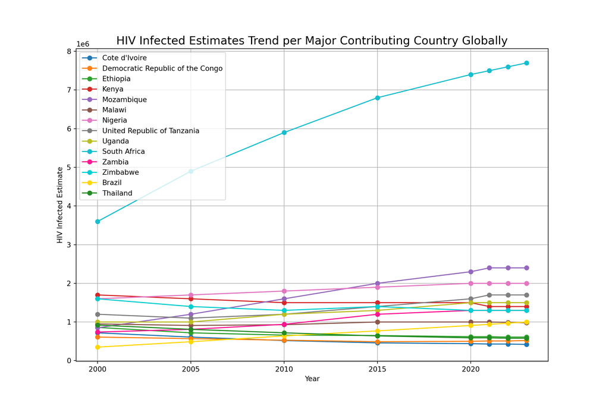

```python
# Create a figure
plt.figure(figsize=(12, 8))

# Define distinct colors for each contries line plot
colors = ['#1f77b4', '#ff7f0e', '#2ca02c', '#d62728', '#9467bd',
          '#8c564b', '#e377c2', '#7f7f7f', '#bcbd22', '#17becf',
         "#ff1493", "#00ced1", "#ffd700", "#228b22"]

# Iterate through each country and plot the trend
for i, location in enumerate(melted_global_trend["Location"].unique()):
    country_data = melted_global_trend[melted_global_trend["Location"] == location]
    plt.plot(country_data["Year"],
             country_data["InfectedEstimate"],
             marker="o", label=location, color=colors[i])

# Set the title, xlabel, ylabel, grid and legend
plt.title(
  "HIV Infected Estimates Trend per Major Contributing Country Globally",
  fontsize=16)
plt.xlabel("Year")
plt.ylabel("HIV Infected Estimate")
plt.grid(True)
plt.legend()

# Display the plot
plt.show()
```

**Section b**  
Generate a visualization that displays the trend of HIV cases in the countries contributing to 75% of the burden within each WHO region (column called `ParentLocationCode` contains the WHO regions)

```python
# melt the pivoted dataframe into long format
melted_regional_df = df.melt(
    id_vars=["ParentLocationCode", "Location"],
    value_vars=year_columns,
    var_name="Year",
    value_name="InfectedEstimate")

# Remove India records from the dataset
melted_regional_df = melted_regional_df[melted_regional_df["Location"] != "India"]
melted_regional_df
```

```
##      ParentLocationCode          Location  Year  InfectedEstimate
## 0                   AFR            Angola  2000          140000.0
## 1                   AFR           Burundi  2000          120000.0
## 2                   AFR             Benin  2000           63000.0
## 3                   AFR      Burkina Faso  2000          150000.0
## 4                   AFR          Botswana  2000          270000.0
## ...                 ...               ...   ...               ...
## 1163                WPR       New Zealand  2023            3600.0
## 1164                WPR       Philippines  2023          190000.0
## 1165                WPR  Papua New Guinea  2023           77000.0
## 1166                WPR         Singapore  2023            8100.0
## 1167                WPR          Viet Nam  2023          250000.0
##
## [1168 rows x 4 columns]
```

```python
# Compute the regional total estimates
region_totals = melted_regional_df.groupby(
    ['ParentLocationCode', 'Year'])['InfectedEstimate'].sum().reset_index(
    name='Region_Total')

# Merge the regional total estimates on the melted dataframe
melted_regional_df = melted_regional_df.merge(
    region_totals, on=['ParentLocationCode', 'Year'])

# Compute the proportions
melted_regional_df['Proportion'] = melted_regional_df['InfectedEstimate'] / melted_regional_df['Region_Total']

melted_regional_df
```

```
##      ParentLocationCode          Location  ... Region_Total  Proportion
## 0                   AFR            Angola  ...   18089000.0    0.007740
## 1                   AFR           Burundi  ...   18089000.0    0.006634
## 2                   AFR             Benin  ...   18089000.0    0.003483
## 3                   AFR      Burkina Faso  ...   18089000.0    0.008292
## 4                   AFR          Botswana  ...   18089000.0    0.014926
## ...                 ...               ...  ...          ...         ...
## 1163                WPR       New Zealand  ...     741970.0    0.004852
## 1164                WPR       Philippines  ...     741970.0    0.256075
## 1165                WPR  Papua New Guinea  ...     741970.0    0.103778
## 1166                WPR         Singapore  ...     741970.0    0.010917
## 1167                WPR          Viet Nam  ...     741970.0    0.336941
##
## [1168 rows x 6 columns]
```

```python
# Compute average proportions across years (per country)
regional_avg_prop = melted_regional_df.groupby(['ParentLocationCode', 'Location'])['Proportion'].mean().reset_index()

# Sort countries by contribution in each region
regional_avg_prop = regional_avg_prop.sort_values(['ParentLocationCode', 'Proportion'], ascending=[True, False])

# Compute cumulative sum of proportions per region
regional_avg_prop['Cumulative_Proportion'] = regional_avg_prop.groupby('ParentLocationCode')['Proportion'].cumsum()

# Filter countries contributing up to 75% of their regional burden
major_regional_contributors = regional_avg_prop[regional_avg_prop['Cumulative_Proportion'] <= 0.75]

major_regional_contributors
```

```
##     ParentLocationCode  ... Cumulative_Proportion
## 35                 AFR  ...              0.278160
## 31                 AFR  ...              0.360822
## 28                 AFR  ...              0.441925
## 20                 AFR  ...              0.509258
## 39                 AFR  ...              0.572603
## 41                 AFR  ...              0.633746
## 38                 AFR  ...              0.691042
## 40                 AFR  ...              0.739261
## 47                 AMR  ...              0.356199
## 61                 AMR  ...              0.482180
## 50                 AMR  ...              0.567322
## 58                 AMR  ...              0.631345
## 42                 AMR  ...              0.682209
## 68                 AMR  ...              0.726770
## 80                 EMR  ...              0.378134
## 72                 EMR  ...              0.520390
## 84                 EMR  ...              0.632843
## 83                 EMR  ...              0.700842
## 125                EUR  ...              0.241700
## 99                 EUR  ...              0.394985
## 122                EUR  ...              0.529764
## 106                EUR  ...              0.651078
## 101                EUR  ...              0.729595
## 133               SEAR  ...              0.491552
## 145                WPR  ...              0.403614
## 136                WPR  ...              0.564036
## 139                WPR  ...              0.707727
##
## [27 rows x 4 columns]
```

```python
# Melt/unpivot the regional trend of HIV Infected estimates
hiv_trend_regional = df[df["Location"].isin(list(major_regional_contributors["Location"]))]

melted_regional_trend = hiv_trend_regional.melt(
    id_vars=["ParentLocationCode", "Location"],
    value_vars=year_columns,
    var_name="Year",
    value_name="InfectedEstimate"
)

melted_regional_trend
```

```
##     ParentLocationCode                     Location  Year  InfectedEstimate
## 0                  AFR                        Kenya  2000         1700000.0
## 1                  AFR                   Mozambique  2000          850000.0
## 2                  AFR                      Nigeria  2000         1600000.0
## 3                  AFR  United Republic of Tanzania  2000         1200000.0
## 4                  AFR                       Uganda  2000         1000000.0
## ..                 ...                          ...   ...               ...
## 211                EUR                      Ukraine  2023          240000.0
## 212               SEAR                     Thailand  2023          580000.0
## 213                WPR                     Cambodia  2023           76000.0
## 214                WPR                     Malaysia  2023           85000.0
## 215                WPR                     Viet Nam  2023          250000.0
##
## [216 rows x 4 columns]
```

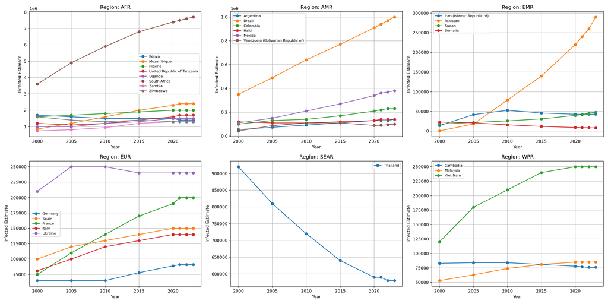

```python
# Create a figure of multiple subplots for each region
fig, axes = plt.subplots(nrows=2, ncols=3, figsize=(20, 10))  # 2 rows x 3 columns = 6 plots
axes = axes.flatten()  # Flatten the 2D array of axes to 1D for easy iteration

# Get all the distinct regions
regions = melted_regional_trend["ParentLocationCode"].unique()

# Iterate through each region and plot the major regional contributing countries
for i, region in enumerate(regions):
    ax = axes[i]
    region_data = melted_regional_trend[melted_regional_trend['ParentLocationCode'] == region]

    for location in region_data['Location'].unique():
        country_data = melted_regional_trend[melted_regional_trend['Location'] == location]
        ax.plot(country_data['Year'], country_data['InfectedEstimate'], marker='o', label=location)

    # Set title, xlabel, ylabel, legend and grid for each plot
    ax.set_title(f'Region: {region}')
    ax.set_xlabel('Year')
    ax.set_ylabel('Infected Estimate')
    ax.legend(fontsize='small')
    ax.grid(True)

# Adjust the plot's layout
plt.tight_layout()

# Display the plot
plt.show()
```

### Part 2

You have also been provided with World Bank data on the multidimensional poverty headcount ratio, which includes factors such as income, educational attainment, school enrolment, electricity access, sanitation and drinking water.

Merge this dataset with the HIV data above and analyze the relationship between people living with HIV and multidimensional poverty, and the individual factors that contribute to the ratio. Remember to account for the random effects (country, year).

Write a paragraph on your findings.

**Clean the Multi-dimensional Dataframe**

```python
multidimensional_df.head()
```

```
##   Individuals in households deprived in each indicator, 110 economies, circa year 2021 (2018-2023)\nDate: October 2024  ...                                   Unnamed: 15
## 0                                             Region                                                                    ...  Multidimensional poverty headcount ratio (%)
## 1                                                NaN                                                                    ...                                           NaN
## 2                                                SSA                                                                    ...                                     47.203606
## 3                                                ECA                                                                    ...                                      0.293161
## 4                                                LAC                                                                    ...                                      0.906573
##
## [5 rows x 16 columns]
```

```python
# Get the columns
multidimensional_df.columns
```

```
## Index(['Individuals in households deprived in each indicator, 110 economies, circa year 2021 (2018-2023)\nDate: October 2024',
##        'Unnamed: 1', 'Unnamed: 2', 'Unnamed: 3', 'Unnamed: 4', 'Unnamed: 5',
##        'Unnamed: 6', 'Unnamed: 7', 'Unnamed: 8', 'Unnamed: 9', 'Unnamed: 10',
##        'Unnamed: 11', 'Unnamed: 12', 'Unnamed: 13', 'Unnamed: 14',
##        'Unnamed: 15'],
##       dtype='object')
```

```python
# Create a column rename mapping
column_mapping = {
    "Individuals in households deprived in each indicator, 110 economies, circa year 2021 (2018-2023)\nDate: October 2024": "Region",
    "Unnamed: 1": "Country code",
    "Unnamed: 2": "Economy",
    "Unnamed: 3": "Reporting year",
    "Unnamed: 4": "Survey name",
    "Unnamed: 5": "Survey year",
    "Unnamed: 6": "Survey coverage",
    "Unnamed: 7": "Welfare type",
    "Unnamed: 8": "Survey comparability",
    "Unnamed: 9": "Monetary",
    "Unnamed: 10": "Educational attainment",
    "Unnamed: 11": "Educational enrollment",
    "Unnamed: 12": "Electricity",
    "Unnamed: 13": "Sanitation",
    "Unnamed: 14": "Drinking water",
    "Unnamed: 15": "Poverty headcount ratio"}

# Rename the columns in the dataframe
md_df = multidimensional_df.rename(columns=column_mapping)

# Remove the rows at index 0 and 1
md_df = md_df.drop(index=[0, 1])
```

```python
md_df.head()
```

```
##   Region Country code  ... Drinking water Poverty headcount ratio
## 2    SSA          AGO  ...      32.106507               47.203606
## 3    ECA          ALB  ...       9.594966                0.293161
## 4    LAC          ARG  ...       0.364048                0.906573
## 5    ECA          ARM  ...       0.660082                0.523521
## 6    EAP          AUS  ...              -                 2.21577
##
## [5 rows x 16 columns]
```

```python
# Calculate the average estimated no. of infected across years for each country
left_df = df.copy()
left_df["AvgInfectedEstimate"] = left_df[year_columns].mean(axis=1)
left_df = left_df[["ParentLocationCode", "Location", "AvgInfectedEstimate"]]
```

```python
# Merge the WHO and Worldbank dataframe on Location
subset_columns = ["Economy", "Monetary", "Educational attainment",
                  "Educational enrollment", "Electricity", "Sanitation",
                  "Drinking water", "Poverty headcount ratio"]
right_df = md_df[subset_columns]
right_df = right_df.rename(columns={"Economy": "Location"})
```

```python
right_df.head()
```

```
##     Location   Monetary  ... Drinking water Poverty headcount ratio
## 2     Angola  31.122005  ...      32.106507               47.203606
## 3    Albania   0.048107  ...       9.594966                0.293161
## 4  Argentina   0.894218  ...       0.364048                0.906573
## 5    Armenia   0.523521  ...       0.660082                0.523521
## 6  Australia    0.51688  ...              -                 2.21577
##
## [5 rows x 8 columns]
```

```python
merged_df = left_df.merge(right_df, how="inner", on="Location")
merged_df.head()
```

```
##   ParentLocationCode       Location  ...  Drinking water Poverty headcount ratio
## 0                AFR         Angola  ...       32.106507               47.203606
## 1                AFR        Burundi  ...       12.021417               79.209852
## 2                AFR          Benin  ...        24.10913                45.44324
## 3                AFR   Burkina Faso  ...       17.327691               52.981192
## 4                AFR  Cote d'Ivoire  ...       17.286547               29.177094
##
## [5 rows x 10 columns]
```

```python
merged_df.info()
```

```
## <class 'pandas.core.frame.DataFrame'>
## RangeIndex: 79 entries, 0 to 78
## Data columns (total 10 columns):
##  #   Column                   Non-Null Count  Dtype
## ---  ------                   --------------  -----
##  0   ParentLocationCode       79 non-null     object
##  1   Location                 79 non-null     object
##  2   AvgInfectedEstimate      79 non-null     float64
##  3   Monetary                 79 non-null     object
##  4   Educational attainment   79 non-null     object
##  5   Educational enrollment   79 non-null     object
##  6   Electricity              79 non-null     object
##  7   Sanitation               79 non-null     object
##  8   Drinking water           79 non-null     object
##  9   Poverty headcount ratio  79 non-null     object
## dtypes: float64(1), object(9)
## memory usage: 6.3+ KB
```

We notice that the `Poverty headcount ratio` as well as the other factors are numeric but are represented as object types in the dataset. Let’s change this.

```python
# Define the numeric columns
numeric_columns = ['Monetary', 'Educational attainment', 'Educational enrollment',
                   'Electricity','Sanitation', 'Drinking water',
                   'Poverty headcount ratio']

# Create a copy of the merged dataframe
numeric_merged_df = merged_df.copy()

# Cast the object types into numeric types
numeric_merged_df[numeric_columns] = numeric_merged_df[numeric_columns].apply(pd.to_numeric, errors="coerce")
```

```python
numeric_merged_df.info()
```

```
## <class 'pandas.core.frame.DataFrame'>
## RangeIndex: 79 entries, 0 to 78
## Data columns (total 10 columns):
##  #   Column                   Non-Null Count  Dtype
## ---  ------                   --------------  -----
##  0   ParentLocationCode       79 non-null     object
##  1   Location                 79 non-null     object
##  2   AvgInfectedEstimate      79 non-null     float64
##  3   Monetary                 79 non-null     float64
##  4   Educational attainment   79 non-null     float64
##  5   Educational enrollment   56 non-null     float64
##  6   Electricity              78 non-null     float64
##  7   Sanitation               63 non-null     float64
##  8   Drinking water           73 non-null     float64
##  9   Poverty headcount ratio  79 non-null     float64
## dtypes: float64(8), object(2)
## memory usage: 6.3+ KB
```

```python
# Remove records with null values on any variable
numeric_merged_df = numeric_merged_df[numeric_merged_df[numeric_columns].notnull().all(axis=1)]

numeric_merged_df.info()
```

```
## <class 'pandas.core.frame.DataFrame'>
## Index: 54 entries, 0 to 78
## Data columns (total 10 columns):
##  #   Column                   Non-Null Count  Dtype
## ---  ------                   --------------  -----
##  0   ParentLocationCode       54 non-null     object
##  1   Location                 54 non-null     object
##  2   AvgInfectedEstimate      54 non-null     float64
##  3   Monetary                 54 non-null     float64
##  4   Educational attainment   54 non-null     float64
##  5   Educational enrollment   54 non-null     float64
##  6   Electricity              54 non-null     float64
##  7   Sanitation               54 non-null     float64
##  8   Drinking water           54 non-null     float64
##  9   Poverty headcount ratio  54 non-null     float64
## dtypes: float64(8), object(2)
## memory usage: 4.6+ KB
```

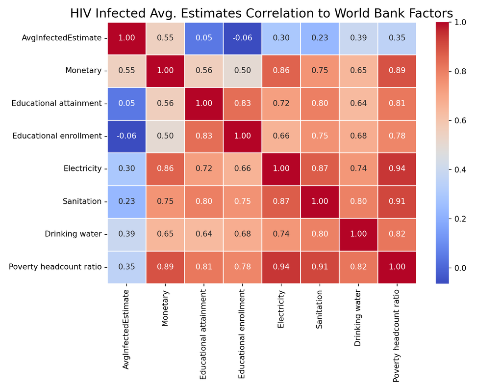

```python
# Select numeric columns
numeric_vars = numeric_merged_df.select_dtypes(include=["float64"])

# Compute the correlation matrix
corr_matrix = numeric_vars.corr()

# Plot the correlation matrix
plt.figure(figsize=(9, 7))
sns.heatmap(corr_matrix, annot=True, cmap="coolwarm", fmt=".2f", linewidths=0.5)
plt.title("HIV Infected Avg. Estimates Correlation to World Bank Factors", fontsize=16)

# Adjust the layout
plt.tight_layout()

# Display the correlation matrix
plt.show()
```

**Results summary**  
South Africa has a significant upward trend compared to countries it shares a region with and globally as well. The African region has more countries contributing to the overall global burden as compared to other regions. In terms of how correlated the Avg. Estimates of HIV infected is to other factors from the World Bank dataset, the Avg. Estimates of HIV Infected is negatively correlated to Educational enrollment albiet a weak negative correlation at -0.06 meaning that as one increases, the other decreases but ever so slightly. The Avg. Estimates of the HIV Infected is moderately, postively correlated to Monetary factor and appears to be the factor with the strongest correlation to Avg. estimates of HIV infected relative to other factors.

## Question 2

You have been provided with data on the under-five mortality rate and neonatal mortality rate for the African region, which has been downloaded from the UN Inter-agency Group for Child Mortality Estimation. Your task is to:

**Section a**  
Filter data for the eight countries belonging to the East African Community (list is [here](https://www.eac.int/overview-of-eac))

```python
child_mort_df.info()
```

```
## <class 'pandas.core.frame.DataFrame'>
## RangeIndex: 129564 entries, 0 to 129563
## Data columns (total 23 columns):
##  #   Column                  Non-Null Count   Dtype
## ---  ------                  --------------   -----
##  0   REF_AREA                129564 non-null  object
##  1   Geographic area         129564 non-null  object
##  2   Regional group          7138 non-null    object
##  3   Indicator               129564 non-null  object
##  4   Sex                     129564 non-null  object
##  5   Wealth Quintile         129564 non-null  object
##  6   Series Name             129564 non-null  object
##  7   Series Year             129564 non-null  object
##  8   Reference Date          129564 non-null  float64
##  9   Observation Value       129528 non-null  float64
##  10  Lower Bound             73949 non-null   float64
##  11  Upper Bound             73949 non-null   float64
##  12  Standard Error          30793 non-null   float64
##  13  Country notes           4710 non-null    object
##  14  Observation Status      129564 non-null  object
##  15  Unit of measure         129564 non-null  object
##  16  Series Type             55615 non-null   object
##  17  Series Category         55615 non-null   object
##  18  Series Method           55615 non-null   object
##  19  Age Group of Women      6295 non-null    object
##  20  Time Since First Birth  760 non-null     object
##  21  Definition              0 non-null       float64
##  22  Interval                118769 non-null  float64
## dtypes: float64(7), object(16)
## memory usage: 22.7+ MB
```

```python
# Get a subset of columns of interest
mort_subset_columns = ["REF_AREA", "Geographic area", "Indicator", "Sex",
                       "Series Year", "Observation Value"]

# Subset the dataframe with the chosen columns
child_mort_df = child_mort_df[mort_subset_columns]

child_mort_df.head()
```

```
##   REF_AREA Geographic area  ... Series Year Observation Value
## 0      AFG     Afghanistan  ...        2018         47.869030
## 1      AFG     Afghanistan  ...        2018         35.349317
## 2      AFG     Afghanistan  ...        2018         27.699219
## 3      AFG     Afghanistan  ...        2018         21.056003
## 4      AFG     Afghanistan  ...        2018         20.167379
##
## [5 rows x 6 columns]
```

```python
# Get the EAC country codes
EAC_codes = ["KEN", "RWA", "SSD", "TZA", "UGA", "SOM", "BDI", "COD"]

# Extract records from EAC countries only
EAC_child_mort = child_mort_df[child_mort_df["REF_AREA"].isin(
    EAC_codes)].reset_index(drop=True)

EAC_child_mort.info()
```

```
## <class 'pandas.core.frame.DataFrame'>
## RangeIndex: 5795 entries, 0 to 5794
## Data columns (total 6 columns):
##  #   Column             Non-Null Count  Dtype
## ---  ------             --------------  -----
##  0   REF_AREA           5795 non-null   object
##  1   Geographic area    5795 non-null   object
##  2   Indicator          5795 non-null   object
##  3   Sex                5795 non-null   object
##  4   Series Year        5795 non-null   object
##  5   Observation Value  5795 non-null   float64
## dtypes: float64(1), object(5)
## memory usage: 271.8+ KB
```

```python
# Rename columns
EAC_child_mort = EAC_child_mort.rename(columns={"REF_AREA": "Ref area", "Geographic area":"Country"})
```

**Section b**  
Visualize the latest estimate of each indicator at the country level using shapefiles, which can be downloaded from here.

```python
# Read in all the EAC country vectors from the shape files
KEN_gdf = gpd.read_file("data/shapefiles/KEN/gadm41_KEN_0.shp")
RWA_gdf = gpd.read_file("data/shapefiles/RWA/gadm41_RWA_0.shp")
SSD_gdf = gpd.read_file("data/shapefiles/SSD/gadm41_SSD_0.shp")
TZA_gdf = gpd.read_file("data/shapefiles/TZA/gadm41_TZA_0.shp")
UGA_gdf = gpd.read_file("data/shapefiles/UGA/gadm41_UGA_0.shp")
SOM_gdf = gpd.read_file("data/shapefiles/SOM/gadm41_SOM_0.shp")
BDI_gdf = gpd.read_file("data/shapefiles/BDI/gadm41_BDI_0.shp")
COD_gdf = gpd.read_file("data/shapefiles/COD/gadm41_COD_0.shp")

# Concatenate the country gdfs
EAC_gdf = pd.concat([KEN_gdf, RWA_gdf, SSD_gdf, TZA_gdf, UGA_gdf, SOM_gdf, BDI_gdf, COD_gdf], ignore_index=True)

# Rename columns
EAC_gdf = EAC_gdf.rename(columns={"GID_0": "Ref area", "COUNTRY": "Country"})

EAC_gdf
```

```
##   Ref area  ...                                           geometry
## 0      KEN  ...  MULTIPOLYGON (((39.38014 -4.71792, 39.37986 -4...
## 1      RWA  ...  POLYGON ((29.71332 -2.81759, 29.71295 -2.81774...
## 2      SSD  ...  POLYGON ((29.79568 4.3843, 29.79645 4.38899, 2...
## 3      TZA  ...  MULTIPOLYGON (((39.35587 -11.09155, 39.34812 -...
## 4      UGA  ...  POLYGON ((29.91125 -1.47687, 29.91099 -1.47613...
## 5      SOM  ...  MULTIPOLYGON (((41.61347 -1.6093, 41.61319 -1....
## 6      BDI  ...  POLYGON ((30.04515 -4.25684, 30.04523 -4.2576,...
## 7      COD  ...  MULTIPOLYGON (((27.24913 -11.79462, 27.2478 -1...
##
## [8 rows x 3 columns]
```

```python
EAC_gdf.columns
```

```
## Index(['Ref area', 'Country', 'geometry'], dtype='object')
```

```python
# Get the latest estimates for both sexes
latest_estimates = EAC_child_mort[(EAC_child_mort["Sex"] == "Total") & (EAC_child_mort["Series Year"] == "2023")]

# Split the latest estimates into Neonatal & Under-five
latest_neonatal_estimates = latest_estimates[latest_estimates["Indicator"] == "Neonatal mortality rate"]
latest_under_five_estimates = latest_estimates[latest_estimates["Indicator"] == "Under-five mortality rate"]

# Aggregate the latest neonatal and under-five mortality rate estimates
avg_neonatal_estimates = latest_neonatal_estimates.groupby("Country").agg(
  {"Observation Value": "mean"}).reset_index()
avg_under_five_estimates = latest_under_five_estimates.groupby("Country").agg({"Observation Value": "mean"}).reset_index()

# Merge the neonatal and under-five aggregated estimates to the EAC geodataframe
avg_neonatal_gdf = EAC_gdf.merge(avg_neonatal_estimates[["Country", "Observation Value"]], on="Country", how="inner")
avg_under_five_gdf = EAC_gdf.merge(avg_under_five_estimates[["Country", "Observation Value"]], on="Country", how="inner")
```

```python
avg_neonatal_gdf.sort_values(by="Observation Value", ascending=False)
```

```
##   Ref area  ... Observation Value
## 2      SSD  ...         50.795190
## 4      SOM  ...         43.848023
## 1      RWA  ...         43.436381
## 3      UGA  ...         37.639283
## 5      BDI  ...         37.454244
## 6      COD  ...         35.549706
## 0      KEN  ...         32.080507
##
## [7 rows x 4 columns]
```

```python
avg_under_five_gdf.sort_values(by="Observation Value", ascending=False)
```

```
##   Ref area  ... Observation Value
## 2      SSD  ...        209.312457
## 4      SOM  ...        181.082823
## 6      COD  ...        138.131068
## 1      RWA  ...        131.064972
## 5      BDI  ...        127.167726
## 3      UGA  ...        120.575784
## 0      KEN  ...         85.821871
##
## [7 rows x 4 columns]
```

```python
# Create a plot of two subplots side by side
fig, (ax1, ax2) = plt.subplots(1, 2, figsize=(20, 10))

# Plot the latest aggregated neonatal mortality rates on EAC spatial vectors
avg_neonatal_gdf.plot(column="Observation Value",
                cmap="OrRd", # Adjust the color mapping to show intensity
                legend=True,
                edgecolor="black",
                linewidth=0.2,
                legend_kwds={
                    "shrink": 0.6, # Adjust the height of the color bar
                },
                ax=ax1)

# Plot the latest aggregated under-five mortality rates on EAC spatial vectors
avg_under_five_gdf.plot(column="Observation Value",
                cmap="OrRd", # Adjust the color mapping to show intensity
                legend=True,
                edgecolor="black",
                linewidth=0.2,
                legend_kwds={
                    "shrink": 0.6, # Adjust the height of the color bar
                },
                ax=ax2)

# Set the titles and remove the the axis boundary for each subplot
ax1.set_title("Avg. Neonatal Mortality Rate per Country (2023)", fontsize=15)
ax2.set_title("Avg. Under-five Mortality Rate per Country (2023)", fontsize=15)
ax1.axis("off")
```

```
## (np.float64(10.240820227500032), np.float64(53.37640332250009), np.float64(-14.736050094549848), np.float64(13.502573671550005))
```

```python
ax2.axis("off")
```

```
## (np.float64(10.240820227500032), np.float64(53.37640332250009), np.float64(-14.736050094549848), np.float64(13.502573671550005))
```

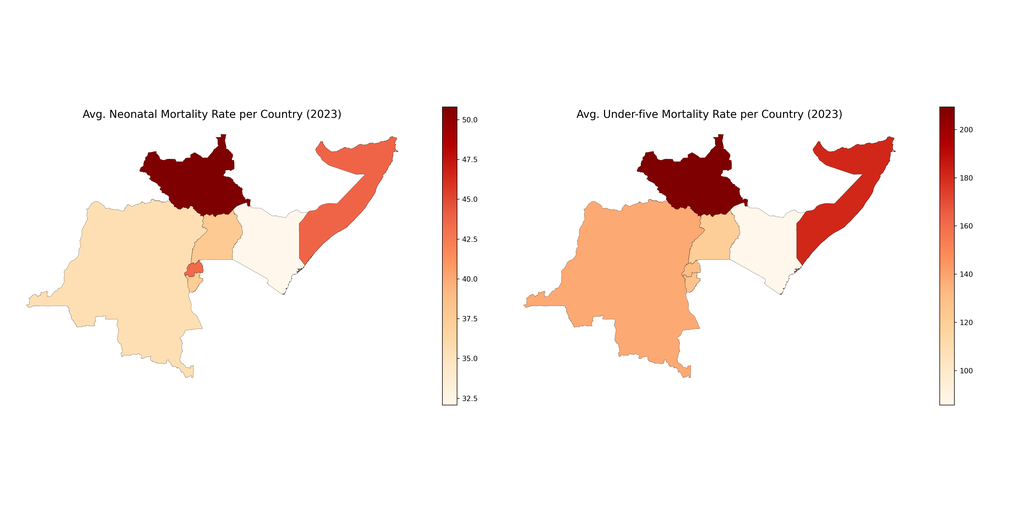

```python
# Tighten the layout and displaly the plot
plt.tight_layout()
plt.show()
```

**Section c**  
Show the average trends in the mortality rates over time (plot the average trend line and add the points in the graphic for the country level estimates for each indicator. Expectation: two plots).

```python
EAC_child_mort.head()
```

```
##   Ref area  Country  ... Series Year Observation Value
## 0      BDI  Burundi  ...   2016-2017          36.41348
## 1      BDI  Burundi  ...   2016-2017          41.25996
## 2      BDI  Burundi  ...   2016-2017          32.83915
## 3      BDI  Burundi  ...   2016-2017          28.46557
## 4      BDI  Burundi  ...   2016-2017          23.70623
##
## [5 rows x 6 columns]
```

```python
# Define a custom function to extract the upper bound of the year
def extract_latest_year(input_string):
    if "-" in input_string:
        latest_year = input_string.split("-")[1]
    else:
        latest_year = input_string
    return latest_year

# Make a copy of the EAC child mortality df
EAC_mort_trend = EAC_child_mort.copy()

# Extract the upper bound of each Series Year in a range format
EAC_mort_trend["Series Year"] = EAC_mort_trend["Series Year"].apply(extract_latest_year)
```

```python
# Subset only the total sex
EAC_mort_trend[EAC_mort_trend["Sex"] == "Total"]
```

```
##      Ref area  Country  ... Series Year Observation Value
## 0         BDI  Burundi  ...        2017         36.413480
## 1         BDI  Burundi  ...        2017         41.259960
## 2         BDI  Burundi  ...        2017         32.839150
## 3         BDI  Burundi  ...        2017         28.465570
## 4         BDI  Burundi  ...        2017         23.706230
## ...       ...      ...  ...         ...               ...
## 5790      UGA   Uganda  ...        2023         45.307572
## 5791      UGA   Uganda  ...        2023         43.509117
## 5792      UGA   Uganda  ...        2023         41.786456
## 5793      UGA   Uganda  ...        2023         40.493282
## 5794      UGA   Uganda  ...        2023         38.807676
##
## [4113 rows x 6 columns]
```

```python
# Remove the Reference Date column
EAC_mort_trend = EAC_mort_trend[["Ref area", "Country", "Indicator", "Sex",
                                 "Series Year", "Observation Value"]]

# Split the dataset into two datasets for the neonatal and under-five mortality
EAC_neonatal_trend = EAC_mort_trend[EAC_mort_trend["Indicator"] == "Neonatal mortality rate"]
EAC_under_five_trend = EAC_mort_trend[EAC_mort_trend["Indicator"] == "Under-five mortality rate"]

# Compute the average trend for both indicators across the years
neonatal_avg_trend = EAC_neonatal_trend.groupby("Series Year")["Observation Value"].mean().reset_index()
under_five_avg_trend = EAC_under_five_trend.groupby("Series Year")["Observation Value"].mean().reset_index()
```

```python
# Create a figure of 2 subplots
fig, (ax1, ax2) = plt.subplots(2, 1, figsize=(16, 16))

# Plot the country points
sns.scatterplot(
    data=EAC_neonatal_trend.sort_values(by="Series Year"),
    x="Series Year",
    y="Observation Value",
    hue="Country",
    alpha=0.6, # transparency
    s=60, # point size
    legend=True,
    ax=ax1
)

# Line plot of the EAC average of neonatal mortality over time
sns.lineplot(
    data=neonatal_avg_trend,
    x="Series Year",
    y="Observation Value",
    linewidth=2.5,
    label="EAC Average Trend",
    ax=ax1
)

# Plot the country points
sns.scatterplot(
    data=EAC_under_five_trend.sort_values(by="Series Year"),
    x="Series Year",
    y="Observation Value",
    hue="Country",
    alpha=0.6,
    s=60,      # size of the points
    legend=True,
    ax=ax2
)

# Line plot of the EAC average of under-five mortality over time
sns.lineplot(
    data=under_five_avg_trend,
    x="Series Year",
    y="Observation Value",
    linewidth=2.5,
    label="EAC Average Trend",
    ax=ax2
)

# Set the respective attributes for the respective axes/plots
ax1.set_title("Yearly Trends of Neonatal Mortality Rates", fontsize=18)
ax1.set_xlabel("Year")
ax1.set_ylabel("Neonatal Mortality Rates")
ax1.legend(
    title="Legend",
    bbox_to_anchor=(0.85, 1),
    loc="upper right",
    fontsize="small",
    title_fontsize="medium")
ax1.grid(True)

ax2.set_title("Yearly Trends of Under-five Mortality Rates", fontsize=18)
ax2.set_xlabel("Year")
ax2.set_ylabel("Under-five Mortality Rates")
ax2.legend(
    title="Legend",
    bbox_to_anchor=(0.85, 1),
    loc="upper right",
    fontsize="small",
    title_fontsize="medium")
ax2.grid(True)
plt.xticks(rotation=45)
```

```
## ([0, 1, 2, 3, 4, 5, 6, 7, 8, 9, 10, 11, 12, 13, 14, 15, 16, 17, 18, 19, 20, 21, 22, 23, 24, 25, 26, 27, 28, 29, 30, 31, 32, 33, 34, 35, 36, 37, 38, 39, 40, 41, 42, 43, 44], [Text(0, 0, '1956'), Text(1, 0, '1965'), Text(2, 0, '1967'), Text(3, 0, '1969'), Text(4, 0, '1970'), Text(5, 0, '1973'), Tex…
```

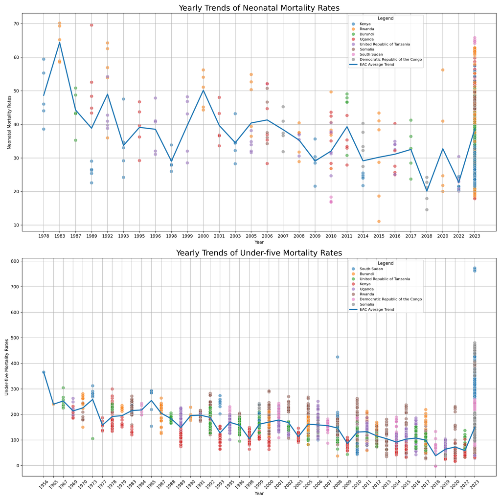

```python
# Adjust the layout
plt.tight_layout()

# Display the plot
plt.show()
```

**Section d**  
Based on your visualizations, identify the countries with the highest under-five mortality rates in East Africa and the highest neonatal mortality.

Top 5 Countries With the Highest Neonatal Mortality Rate

- South Sudan
- Somalia
- Rwanda
- Uganda
- Burundi

Top 5 Countries With the Highest Under-five Mortality Rate

- South Sudan
- Somalia
- Democratic Republic of Congo
- Rwanda
- Burundi